# Análisis de regresión lineal

Regresión lineal múltiple

Luis Fernando Apáez Álvarez

7/1/2022

Otras formas de definir el mismo modelo en R

Regresamos al modelo

Interpretación del modelo

Visualización

## Caso cuando alguna $x_{i}$ es categórica

Cargamos y vemos los datos

```r
Datos=read.csv("ejemplo3RLM.csv", header=TRUE )

summary(Datos)
```

```
##        y              X1c                  X2
##  Min.   :-2.093   Length:300         Min.   :-1.618
##  1st Qu.: 3.793   Class :character   1st Qu.: 1.848
##  Median : 5.528   Mode  :character   Median : 2.912
##  Mean   : 5.704                      Mean   : 3.069
##  3rd Qu.: 7.538                      3rd Qu.: 4.264
##  Max.   :15.984                      Max.   : 9.482
```

```r
str(Datos)
```

```
## 'data.frame':    300 obs. of  3 variables:
##  $ y  : num  3.25 4.23 9.58 5.11 5.34 ...
##  $ X1c: chr  "A1" "A1" "A1" "A1" ...
##  $ X2 : num  1.88 2.54 6.12 3.14 3.26 ...
```

vemos que la variable `x1c` viene como cadena. Realizamos las transformaciones correspondientes

```r
Datos$X1c=factor(Datos$X1c)
str(Datos)
```

```
## 'data.frame':    300 obs. of  3 variables:
##  $ y  : num  3.25 4.23 9.58 5.11 5.34 ...
##  $ X1c: Factor w/ 3 levels "A1","A2","A3": 1 1 1 1 1 1 1 1 1 1 ...
##  $ X2 : num  1.88 2.54 6.12 3.14 3.26 ...
```

Después graficamos

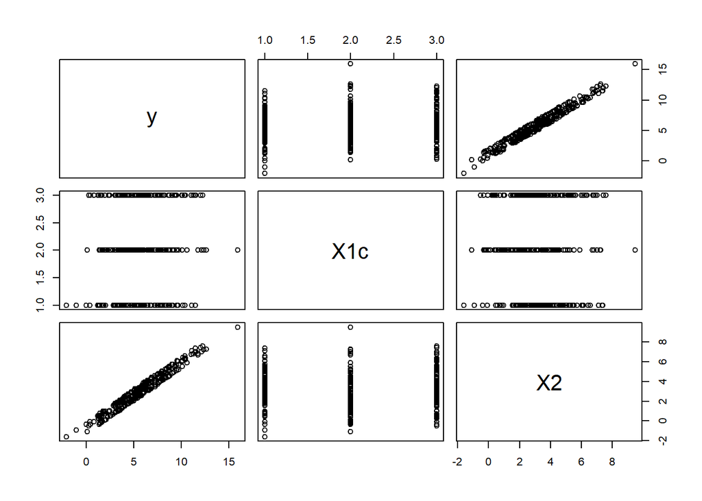

```r
par(mfrow=c(1,1),mar=c(4.5,4.5,1,1))
plot(Datos)
```

La gráfica de nuestro interés es la siguiente, que además hemos agregado color (lo que siempre es recomendable)

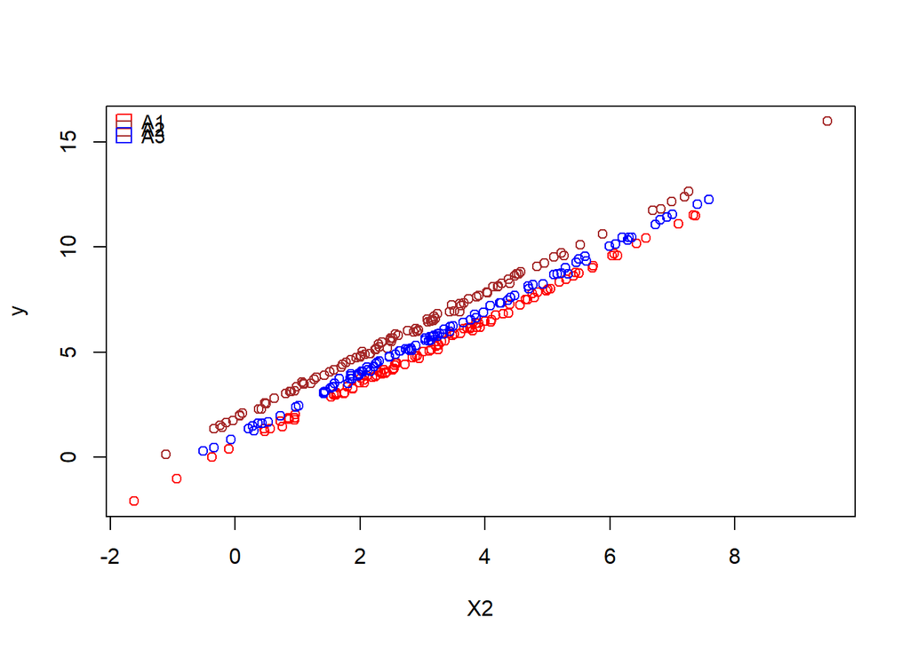

```r
with(Datos, plot(X2, y, col=c("red", "brown", "blue")[Datos[,2]] ))
legend("topleft",levels(Datos[,2]), col=c("red", "brown", "blue"), pch = c(0,0,0),  pt.cex=1.5,cex = .9, y.intersp = 0.3 , bty="n")
```

donde comparamos la relación de la variable $X_{2}$ con la $y$ y adicionalmente la posible información que podría brindar la variable categórica. Después vemos los niveles de `x1c`

```r
levels(Datos$X1c)
```

```
## [1] "A1" "A2" "A3"
```

de modo que el modelo con el que estamos trabajando es

$$\mathbb{E}(y|x)=\beta_{0}+\beta_{1}A_2 + \beta_{2}A_{3}+ \beta_{3}X_{2}$$

donde $A_{2}$ y $A_{3}$ son variables dicotómicas y $X_{2}$ es la variable continua.

```r
fit=lm(y~X1c+X2, data=Datos)
summary(fit)
```

```
##
## Call:
## lm(formula = y ~ X1c + X2, data = Datos)
##
## Residuals:
##       Min        1Q    Median        3Q       Max
## -0.277652 -0.060507  0.003333  0.065288  0.261476
##
## Coefficients:
##             Estimate Std. Error t value Pr(>|t|)
## (Intercept) 0.505342   0.013849   36.49   <2e-16 ***
## X1cA2       1.313092   0.014053   93.44   <2e-16 ***
## X1cA3       0.499562   0.014002   35.68   <2e-16 ***
## X2          1.497182   0.003044  491.78   <2e-16 ***
## ---
## Signif. codes:  0 '***' 0.001 '**' 0.01 '*' 0.05 '.' 0.1 ' ' 1
##
## Residual standard error: 0.099 on 296 degrees of freedom
## Multiple R-squared:  0.9988, Adjusted R-squared:  0.9988
## F-statistic: 8.162e+04 on 3 and 296 DF,  p-value: < 2.2e-16
```

Analicemos la Interpretación del modelo con estos parámetros. Después regresaremos a la prueba asociada a la tabla ANOVA.

Aquí $\mathbb{E}(y|x1c, x2)=\beta_0+\beta_1 A_2+\beta_2 A_3+\beta_3 x_2$ con el nivel de referencia igual a A1, además notar que en este caso, si consideramos que `x1c` toma el valor del nivel A1,entonces el modelo para $\mathbb{E}(Y|x1c=A_1,x_2)$ es

$$\mathbb{E}(Y|x1c=A_1,x_2)=\beta_0+\beta_1(0)+\beta_2(0)+\beta_3x_2 =\beta_0+\beta_3x_2$$

para nivel A2: $\mathbb{E}(Y|x1c=A_2,x_2)$

$$\mathbb{E}(Y|x1c=A_1,x_2)=\beta_0+\beta_1(1)+\beta_2(0)+\beta_3x_2 =(\beta_0+\beta_{1})+\beta_3x_2$$

para nivel A3: $\mathbb{E}(Y|x1c=A_3,x_2)$

$$\mathbb{E}(Y|x1c=A_1,x_2)=\beta_0+\beta_1(0)+\beta_2(1)+\beta_3x_2 =(\beta_0+\beta_{2})+\beta_3x_2$$

Es decir, con este modelo se considera que la $\mathbb{E}(Y|x1c,x_2)$ es una recta en función del valor de $x_2$ para cada nivel, con diferente intercepto pero misma pendiente (lo cual se veía en la gráfica de las tres rectas coloreadas).

### Otras formas de definir el mismo modelo en R (cuestiones computacionales)

- Indicando las 2 variebles dicótomicas (niveles) que deben entrar al modelo

  ```r
  fitAlt=lm(y~I(X1c=="A2")+I(X1c=="A3")+X2, data=Datos)
  summary(fitAlt)
  ```

  ```
  ##
  ## Call:
  ## lm(formula = y ~ I(X1c == "A2") + I(X1c == "A3") + X2, data = Datos)
  ##
  ## Residuals:
  ##       Min        1Q    Median        3Q       Max
  ## -0.277652 -0.060507  0.003333  0.065288  0.261476
  ##
  ## Coefficients:
  ##                    Estimate Std. Error t value Pr(>|t|)
  ## (Intercept)        0.505342   0.013849   36.49   <2e-16 ***
  ## I(X1c == "A2")TRUE 1.313092   0.014053   93.44   <2e-16 ***
  ## I(X1c == "A3")TRUE 0.499562   0.014002   35.68   <2e-16 ***
  ## X2                 1.497182   0.003044  491.78   <2e-16 ***
  ## ---
  ## Signif. codes:  0 '***' 0.001 '**' 0.01 '*' 0.05 '.' 0.1 ' ' 1
  ##
  ## Residual standard error: 0.099 on 296 degrees of freedom
  ## Multiple R-squared:  0.9988, Adjusted R-squared:  0.9988
  ## F-statistic: 8.162e+04 on 3 and 296 DF,  p-value: < 2.2e-16
  ```

- Cambiando el nivel de referencia que tiene por default `R`. Aquí hay que obtener de nuevo las expresiones de $\mathbb{E}(Y|x1c=A1,x_2)$, $\mathbb{E}(Y|x1c=A_2,x_2)$ y $\mathbb{E}(Y|x1c=A_3,x_2)$

  ```r
  fitAlt2=lm(y~relevel(X1c, "A3")+X2, data=Datos)
  summary(fitAlt2)
  ```

  ```
  ##
  ## Call:
  ## lm(formula = y ~ relevel(X1c, "A3") + X2, data = Datos)
  ##
  ## Residuals:
  ##       Min        1Q    Median        3Q       Max
  ## -0.277652 -0.060507  0.003333  0.065288  0.261476
  ##
  ## Coefficients:
  ##                       Estimate Std. Error t value Pr(>|t|)
  ## (Intercept)           1.004904   0.013977   71.89   <2e-16 ***
  ## relevel(X1c, "A3")A1 -0.499562   0.014002  -35.68   <2e-16 ***
  ## relevel(X1c, "A3")A2  0.813530   0.014070   57.82   <2e-16 ***
  ## X2                    1.497182   0.003044  491.78   <2e-16 ***
  ## ---
  ## Signif. codes:  0 '***' 0.001 '**' 0.01 '*' 0.05 '.' 0.1 ' ' 1
  ##
  ## Residual standard error: 0.099 on 296 degrees of freedom
  ## Multiple R-squared:  0.9988, Adjusted R-squared:  0.9988
  ## F-statistic: 8.162e+04 on 3 and 296 DF,  p-value: < 2.2e-16
  ```

  ```r
  fitAlt3=lm(y~I(X1c=="A1")+I(X1c=="A2")+X2, data=Datos)
  summary(fitAlt3)
  ```

  ```
  ##
  ## Call:
  ## lm(formula = y ~ I(X1c == "A1") + I(X1c == "A2") + X2, data = Datos)
  ##
  ## Residuals:
  ##       Min        1Q    Median        3Q       Max
  ## -0.277652 -0.060507  0.003333  0.065288  0.261476
  ##
  ## Coefficients:
  ##                     Estimate Std. Error t value Pr(>|t|)
  ## (Intercept)         1.004904   0.013977   71.89   <2e-16 ***
  ## I(X1c == "A1")TRUE -0.499562   0.014002  -35.68   <2e-16 ***
  ## I(X1c == "A2")TRUE  0.813530   0.014070   57.82   <2e-16 ***
  ## X2                  1.497182   0.003044  491.78   <2e-16 ***
  ## ---
  ## Signif. codes:  0 '***' 0.001 '**' 0.01 '*' 0.05 '.' 0.1 ' ' 1
  ##
  ## Residual standard error: 0.099 on 296 degrees of freedom
  ## Multiple R-squared:  0.9988, Adjusted R-squared:  0.9988
  ## F-statistic: 8.162e+04 on 3 and 296 DF,  p-value: < 2.2e-16
  ```

  El efecto de la función `relevel`:

  ```r
  levels(Datos$X1c)
  ```

  ```
  ## [1] "A1" "A2" "A3"
  ```

  ```r
  Datos$X1c=relevel(Datos$X1c, "A3")
  levels(Datos$X1c)
  ```

  ```
  ## [1] "A3" "A1" "A2"
  ```

  El efecto de la función factor

  ```r
  Datos$X1c=factor(Datos$X1c, levels=c("A1","A2","A3"))
  levels(Datos$X1c)
  ```

  ```
  ## [1] "A1" "A2" "A3"
  ```

### Regresemos al modelo

```r
summary(fit)
```

```
##
## Call:
## lm(formula = y ~ X1c + X2, data = Datos)
##
## Residuals:
##       Min        1Q    Median        3Q       Max
## -0.277652 -0.060507  0.003333  0.065288  0.261476
##
## Coefficients:
##             Estimate Std. Error t value Pr(>|t|)
## (Intercept) 0.505342   0.013849   36.49   <2e-16 ***
## X1cA2       1.313092   0.014053   93.44   <2e-16 ***
## X1cA3       0.499562   0.014002   35.68   <2e-16 ***
## X2          1.497182   0.003044  491.78   <2e-16 ***
## ---
## Signif. codes:  0 '***' 0.001 '**' 0.01 '*' 0.05 '.' 0.1 ' ' 1
##
## Residual standard error: 0.099 on 296 degrees of freedom
## Multiple R-squared:  0.9988, Adjusted R-squared:  0.9988
## F-statistic: 8.162e+04 on 3 and 296 DF,  p-value: < 2.2e-16
```

Consideramos la prueba F asociada a la tabla anova.

Observemos que con la prueba asociada a la tabla ANOVA, se puede concluir que con una significancia de .05, se rechaza $H_0$ en el contraste

$$H_0: \beta_1=0\ \ y\ \ \beta_2=0 \ \ y \ \ \beta_3=0 \ \ vs\ \ H_a: \beta_1\neq0\ \ o \ \ \beta_2\neq0\ \ o\ \ \beta_3\neq0$$

Además, si analizamos la prueba t, para el coeficiente $\beta_3$, asociado a $X_2$, podemos observar que se rechaza $H_0$ en el contraste $H_0: \beta_3=0\ \ vs\ \ Ha: \beta_3 \neq 0$,esto nos indicaría que una vez incluida la variablecategórica X1c en el modelo, la variable $X_2$ está agregando información.

Para analizar si la variable X1c agrega información dado que el modelo incluye a $X_2$, debemos constrastar $H_0: \beta_1=0\ \ y \ \ \beta_2=0\ \ vs\ \ H_a: \beta_1\neq0 \ \ o \ \ \beta_2\neq0$. En este caso se debe tener cuidado puesto que no podemos emplear el mismo análisis anterior dado que x1c es categórica.

```r
#Opción 1, usando multcomp
library(multcomp)
K=matrix(c(0,1,0,0,
           0,0,1,0), ncol=4, nrow=2, byrow=TRUE)
m=c(0,0)
summary(glht(fit, linfct=K, rhs=m), test=Ftest())
```

```
##
##   General Linear Hypotheses
##
## Linear Hypotheses:
##        Estimate
## 1 == 0   1.3131
## 2 == 0   0.4996
##
## Global Test:
##      F DF1 DF2     Pr(>F)
## 1 4442   2 296 1.763e-221
```

se rechaza $H_{0}$ entonces la variable X1c nos proporciona información para modelar $\mathbb{E}(Y|x)$ aún cuando en el modelo ya está la variable $X_2$.

```r
#Opción 2, usando anova con modelos reducidos
fitred=lm(y~X2, data=Datos)
anova(fitred, fit)
```

```
## Analysis of Variance Table
##
## Model 1: y ~ X2
## Model 2: y ~ X1c + X2
##   Res.Df    RSS Df Sum of Sq      F    Pr(>F)
## 1    298 89.985
## 2    296  2.901  2    87.084 4442.3 < 2.2e-16 ***
## ---
## Signif. codes:  0 '***' 0.001 '**' 0.01 '*' 0.05 '.' 0.1 ' ' 1
```

de igual manera el $p-value$ es pequeño.

```r
#Opción 3, usar directamente la función drop1
drop1(fit, test = "F")
```

```
## Single term deletions
##
## Model:
## y ~ X1c + X2
##        Df Sum of Sq     RSS      AIC  F value    Pr(>F)
## <none>                 2.90 -1383.59
## X1c     2     87.08   89.99  -357.24   4442.3 < 2.2e-16 ***
## X2      1   2370.54 2373.44   626.49 241851.0 < 2.2e-16 ***
## ---
## Signif. codes:  0 '***' 0.001 '**' 0.01 '*' 0.05 '.' 0.1 ' ' 1
```

```r
#Opcón 4, usar directamente la función Anova en librería car
library(car)
Anova(fit, type="II")
```

```
## Anova Table (Type II tests)
##
## Response: y
##            Sum Sq  Df  F value    Pr(>F)
## X1c         87.08   2   4442.3 < 2.2e-16 ***
## X2        2370.54   1 241851.0 < 2.2e-16 ***
## Residuals    2.90 296
## ---
## Signif. codes:  0 '***' 0.001 '**' 0.01 '*' 0.05 '.' 0.1 ' ' 1
```

Notar que lo anterior sólo se vale cuando la variable categórica aparece en el modelo sólo a través de sus $k-1$ variables dicotómicas (no hay interacciones entre variables).

Por otro lado, si analizamos la prueba t, para el coeficiente $\beta_1$, se rechaza $H_0$. Aquí el contraste es $H_0: \beta_1=0\ \ vs\ \ H_a: \beta_1 \neq 0$. Esto nos indica, que condicional en un valor fijo de $X_2$, la esperanza de $Y$ es diferente entre el nivel $A_2$ y el $A_1$ (de referencia).

Ahora, si analizamos la prueba t, para el coeficiente $\beta_2$, se rechaza $H_0$. Aquí el contraste es $H_0:\ beta_2=0\ \ vs\ \ H_a: \beta_2 \neq 0$. Esto nos indica, que condicional en un valor fijo de $X_2$, la esperanza de $Y$ es diferente entre el nivel $A_3$ y el $A_1$ (de referencia)

Con base en lo anterior, parece que no podríamos reducir el modelo, todos los coeficientes parecen significativos.

### Interpretación del modelo

```r
summary(fit)
```

```
##
## Call:
## lm(formula = y ~ X1c + X2, data = Datos)
##
## Residuals:
##       Min        1Q    Median        3Q       Max
## -0.277652 -0.060507  0.003333  0.065288  0.261476
##
## Coefficients:
##             Estimate Std. Error t value Pr(>|t|)
## (Intercept) 0.505342   0.013849   36.49   <2e-16 ***
## X1cA2       1.313092   0.014053   93.44   <2e-16 ***
## X1cA3       0.499562   0.014002   35.68   <2e-16 ***
## X2          1.497182   0.003044  491.78   <2e-16 ***
## ---
## Signif. codes:  0 '***' 0.001 '**' 0.01 '*' 0.05 '.' 0.1 ' ' 1
##
## Residual standard error: 0.099 on 296 degrees of freedom
## Multiple R-squared:  0.9988, Adjusted R-squared:  0.9988
## F-statistic: 8.162e+04 on 3 and 296 DF,  p-value: < 2.2e-16
```

$R^2$, el coeficiente de determinación, nos indica que se está explicando el $99.9\%$ de la variabilidad observada en $Y$ a través del modelo que incluye ambas variables X1c y $X_2$: $\mathbb{E}(y|X1c, X_2)=\beta_0+\beta_1A_2+\beta_2A_3+\beta_3X_2$.

Además, b1 se puede interpretar como: condicionado en un valor fijo de $X_2$, el promedio de la variable. Y aumenta en 1.31 unidades al comparar el nivel $A_2$ contra el $A_1$. (mayor esperanza en nivel $A_2$ contra nivel $A_1$). Recordar que nivel $A_1$ es el de referencia en este modelo. Esta interpretación se obtiene al comparar

$$\mathbb{E}(Y|A_2, X_2)-\mathbb{E}(Y|A_1, X_2)=\beta_0+\beta_1+\beta_3 X_2-(\beta_0+\beta_3 x_2)=\beta_1$$

$\beta_2$ se puede interpretar como: condicionado en un valor fijo de $X_2$, el promedio de la variable $Y$ aumenta en .5 unidades al comparar el nivel $A_3$ contra el $A_1$.

$\beta_3$ se puede interpretar como: condicionado en un nivel fijo de la variable X1c, el promedio de la variable $Y$ aumenta en 1.5 unidades al aumentar en una unidad la variable $X_2$.

¿Cómo se comparan los niveles A2 y A3, dado un valor fijo de X2?

$$\begin{align*}
&\mathbb{E}(Y|A_2, X_2)=\beta_0+\beta_1+\beta_3 X_2\\
&\mathbb{E}(Y|A_3, X_2)=\beta_0+\beta_2+\beta_3 X_2
\end{align*}$$

entonces

$$\mathbb{E}(Y|A_3, X_2)-\mathbb{E}(Y|A_2, X_2)=\beta_2-\beta_1$$

Por ejemplo si se tiene interés en contrastar

$$H_0:\mathbb{E}(Y|A_2, X_2)=\mathbb{E}(Y|A_3, X_2)\ \ vs\ \ H_a:\mathbb{E}(Y|A_2, X_2)\neq \mathbb{E}(Y|A_3, X_2)$$

Se puede usar multcomp

```r
library(multcomp)
K=matrix(c(0,-1,1,0), ncol=4, nrow=1, byrow=TRUE)
m=c(0)
summary(glht(fit, linfct=K, rhs=m), test=Ftest())
```

```
##
##   General Linear Hypotheses
##
## Linear Hypotheses:
##        Estimate
## 1 == 0  -0.8135
##
## Global Test:
##      F DF1 DF2     Pr(>F)
## 1 3343   1 296 2.545e-163
```

```r
summary(glht(fit, linfct=K, rhs=m))
```

```
##
##   Simultaneous Tests for General Linear Hypotheses
##
## Fit: lm(formula = y ~ X1c + X2, data = Datos)
##
## Linear Hypotheses:
##        Estimate Std. Error t value Pr(>|t|)
## 1 == 0 -0.81353    0.01407  -57.82   <2e-16 ***
## ---
## Signif. codes:  0 '***' 0.001 '**' 0.01 '*' 0.05 '.' 0.1 ' ' 1
## (Adjusted p values reported -- single-step method)
```

Se rechaza la igualdad de medias, es decir, dado un valor de $X_2$, la esperanza de $Y$ es diferente entre los niveles $A_3$ y $A_2$. De hecho, la esperanza disminuye en .8135 unidades al comparar el nivel $A_3$ contra el $A_2$.

### Visualización de los resultados del modelo

$\mathbb{E}(y|X1c,X_2)=\beta_0+\beta_1A_2+\beta_2A_3+\beta_3 X_2$

Recordar que en este caso, el modelo se relaciona con tres rectas, una por nivel. Además recordemos que como función de $X_2$, son tres rectas que tienen diferente intercepto pero misma pendiente $\beta_3$

```r
fit$coefficients
```

```
## (Intercept)       X1cA2       X1cA3          X2
##   0.5053418   1.3130916   0.4995617   1.4971818
```

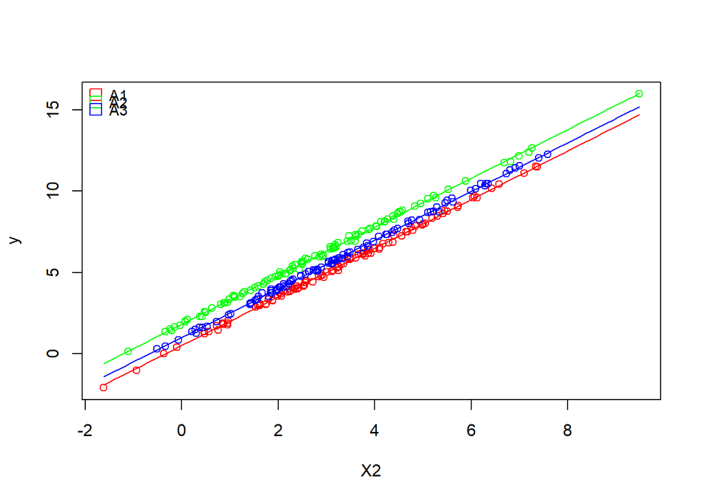

```r
#coef(fit)
fA1 <- function(X2) {fit$coefficients[1]+ fit$coefficients[4]*X2}
fA2 <- function(X2) {fit$coefficients[1]+fit$coefficients[2]+ fit$coefficients[4]*X2}
fA3 <- function(X2) {fit$coefficients[1]+fit$coefficients[3]+ fit$coefficients[4]*X2}

with(Datos, plot(X2, y, col=c("red", "green", "blue")[Datos[,2]] ))
legend("topleft",levels(Datos[,2]), col=c("red", "green", "blue"), pch = c(0,0,0), pt.cex=1.5,cex = .9, y.intersp = 0.4 , bty="n" )
curve(fA1, from = min(Datos$X2), to = max(Datos$X2),
      col = "red", add = T)
curve(fA2, from = min(Datos$X2), to = max(Datos$X2),
      col = "green", add = T)
curve(fA3, from = min(Datos$X2), to = max(Datos$X2),
      col = "blue", add = T)
```